# Exploring the relationship between common AFL statistics & winning margin

Tom Perkins

11 August 2020

Round 11s match of the 2020 AFL season between Port Adelaide & Richmond has been widely praised as the “best game of the season”. A fast-finishing Port Adelaide prevailed by 21 points. Despite being a close game, match-reports appear to show the game was statistically dominated by Port Adelaide

Consider [ESPNs](https://www.espn.com.au/afl/matchup?gameId=1070341) summary

Port Adelaide were

- +43 in contested possessions
- +31 for inside 50s
- +80 for total possessions

Despite these discrepancies, the game was close for most of the day, with Richmond even leading at 3/4 time

This had me wondering how important commonly measured AFL statistics are to the end result?

To better understand this, I have aggregated all AFL match-day statistics for season 2019, & looked at the relationship between game-day stats & the eventual winning margin of the game

Specifically I have focused upon:

**“differential statistics”** - what was the difference between the winning & losing side for metric x, y or z?

Below I have outlined the programming to do this

## The Data

[AFLTables](https://afltables.com/afl/afl_index.html) & [Footywire](https://www.footywire.com/) are undoubtedly the best independent online resources for footy-related statistics

R users are fortunate that the vast depth of statistics from these websites are easily accessible via the **[“FitzRoy”](https://cran.r-project.org/web/packages/fitzRoy/index.html)** package

Let’s read-in FitzRoy, and all other packages we will use for analysis

```r
# Data extraction
library(devtools)
library(fitzRoy)
# Data cleaning
library(snakecase)
library(tidyr)
library(dplyr)
library(reshape)
library(knitr)
# Data visualisation
library(kableExtra)
library(corrplot)
library(taucharts)
library(kableExtra)
# Data analysis
library(ClustOfVar)
library(cluster)
```

FitzRoy provides a straight-forward function to read-in data from Footywire (*“get_footywire_stats”*). The only required input is which matches to include in the data-extract via the websites **Match_ids**

The range of “match_ids” has been limited to the 207 games contested in the 2019 season. Match_ids can be identified via the web-URL for each game on FootyWire

I encountered some buggy-behaviour reading in every required match in a single line of code, but found splitting it out worked OK

The match-data from footywire takes ~ 10-15 minutes to read, so patience is required :)

```r
# Extract all games from 2019 AFL season
footywire2 <- get_footywire_stats(ids = 9876:9927)
footywire1 <- get_footywire_stats(ids = 9721:9875)
```

```r
# Extract all games from 2020 AFL season
footywire3A <- get_footywire_stats(ids = 9928:9936)
footywire3B <- get_footywire_stats(ids = 10126:10141)
footywire3BB <- get_footywire_stats(ids = 10143:10152)
footywire3C <- get_footywire_stats(ids = 10182:10190)
```

```r
footywire3D <- get_footywire_stats(ids = 10209:10326)
```

```r
# Extract all games from 2018 AFL season
footywire4 <- get_footywire_stats(ids = 9514:9720)
```

```r
# Extract all games from 2017 AFL season
footywire5 <- get_footywire_stats(ids = 9307:9513)
```

```r
# Bind into a single data-frame
Season2017to2020 <- rbind(footywire1, footywire2, footywire3A, footywire3B, footywire3BB, footywire3C, footywire3D, footywire4, footywire5)
# lower case, under_score all column titles
names(Season2017to2020) <- to_snake_case(names(Season2017to2020))
# remove original extracts
# footywire1 <- NULL
# footywire2 <- NULL
```

The structure of this data-extract is 207 games x 44 selected players for each game, which produces 9108 rows of data

Each row reports the statistics of an individual player in every game

This affords great flexibility to explore both match-level and player-level statistics

| date | season | round | venue | player | team | opposition | status | match_id | cp | up | ed | de | cm | ga_15 | mi_5 | one_percenters | bo | ccl | scl | si | mg | to | itc | t_5 | tog | k | hb | d | m | … |
| --- | --- | --- | --- | --- | --- | --- | --- | --- | --- | --- | --- | --- | --- | --- | --- | --- | --- | --- | --- | --- | --- | --- | --- | --- | --- | --- | --- | --- | --- | --- |
| 2019-03-21 | 2019 | Round 1 | MCG | Patrick Cripps | Carlton | Richmond | Home | 9721 | 21 | 11 | 26 | 81.2 | 0 | 0 | 0 | 0 | 1 | 4 | 3 | 5 | 263 | 3 | 4 | 0 | 89 | 10 | 22 | 32 | 1 | … |
| 2019-03-21 | 2019 | Round 1 | MCG | Marc Murphy | Carlton | Richmond | Home | 9721 | 6 | 23 | 21 | 72.4 | 0 | 0 | 0 | 0 | 0 | 0 | 1 | 7 | 530 | 5 | 3 | 0 | 87 | 16 | 13 | 29 | 4 | … |
| 2019-03-21 | 2019 | Round 1 | MCG | Kade Simpson | Carlton | Richmond | Home | 9721 | 5 | 19 | 21 | 77.8 | 0 | 0 | 0 | 1 | 0 | 1 | 1 | 2 | 462 | 2 | 6 | 0 | 84 | 15 | 12 | 27 | 6 | … |
| 2019-03-21 | 2019 | Round 1 | MCG | Dale Thomas | Carlton | Richmond | Home | 9721 | 6 | 17 | 23 | 85.2 | 0 | 1 | 0 | 4 | 0 | 0 | 0 | 8 | 434 | 4 | 6 | 0 | 78 | 15 | 12 | 27 | 3 | … |
| 2019-03-21 | 2019 | Round 1 | MCG | Nic Newman | Carlton | Richmond | Home | 9721 | 5 | 17 | 22 | 84.6 | 0 | 0 | 0 | 3 | 0 | 0 | 1 | 4 | 584 | 2 | 6 | 0 | 84 | 21 | 5 | 26 | 9 | … |
| 2019-03-21 | 2019 | Round 1 | MCG | Edward Curnow | Carlton | Richmond | Home | 9721 | 7 | 18 | 18 | 72.0 | 0 | 1 | 2 | 1 | 0 | 0 | 2 | 8 | 303 | 6 | 0 | 2 | 82 | 13 | 12 | 25 | 12 | … |

## Re-shape & aggregate

Two key steps required to to transform this data for analysis are:

- Aggregate the data so each row reflects match-level statistics rather than player level, &
- Pivot the data so every row reflects a unique game of the season

We will use several “tidyverse” functions to first aggregate our match-level statistics

```r
# tally up all key statistics per game, per team
Ag <- Season2017to2020 %>%
  dplyr::select(season,
         round,
         date,
         team,
         opposition,
         status,
         cp, # CONTESTED POSSESSION
         up, # UNCONTESTED POSSESSION
         de, # DISPOSAL EFFICIENCY
         one_percenters, # ONE PERCENTERS
         mg, # METRES GAINED
         to, # TURNOVER
         k, # KICKS
         hb, # HANDBALLS
         d, # DISPOSALS
         m, # MARK
         i_50, # INSIDE 50
         cl, # CLEARANCE
         cg, # CLANGERS
         r_50, # REBOUND 50
         ff, # FREES FOR
         fa, # FREES AGAINST
         cm, # CONTESTED MARKS
         ga_15, # GOAL ASSISTS
         bo, # BOUNCES
         ccl, # CENTRE CLEARANCES
         scl, # STOPPAGE CLEARANCE
         itc, # INTERCEPTS
         si, # SCORE INVOLVEMENTS
         t_5, # TACKLES INSIDE 50
         match_id) %>%
  group_by(match_id,
           team,
           opposition,
           status,
           season,
           round,
           date) %>%
  summarise(
    CP = sum(cp),
    UP = sum(up),
    DE = round(mean(de),1),
    OP = sum(one_percenters),
    MG = round(sum(mg),1),
    TO = sum(to),
    K = sum(k),
    HB = sum(hb),
    D = sum(d),
    M = sum(m),
    I50 = sum(i_50),
    CL = sum(cl),
    CG = sum(cg),
    R50 = sum(r_50),
    FF = sum(ff),
    FA = sum(fa),
    CM = sum(cm),
    GA = sum(ga_15),
    BO = sum(bo),
    CCL = sum(ccl),
    SCL = sum(scl),
    ITC = sum(itc),
    SI = sum(si),
    T5 = sum(t_5),
  )
```

However, we have one further issue to address: Data for each match is split across two rows - one for the home team, the other for the away team. The required end-state is for data from both teams to be summarized in a single row

The dplyr function **spread** can *almost* solve this issue. However, it only accepts one “value” argument & we therefore are not able to pivot over multiple variables

Fortunately, clever user [danr from the R Studio Community](https://community.rstudio.com/t/spread-with-multiple-value-columns/5378/2) wrote a function augmenting the spread-command to be able to do this. We will implement this below:

```r
# remove opposition
Ag$opposition <- NULL

# Function to spread across multiple values
myspread <- function(df, key, value) {
  # quote key
  keyq <- rlang::enquo(key)
  # break value vector into quotes
  valueq <- rlang::enquo(value)
  s <- rlang::quos(!!valueq)
  df %>% gather(variable, value, !!!s) %>%
    unite(temp, !!keyq, variable) %>%
    spread(temp, value)
}

# spread - so each row reflects a single game
Ag <- Ag %>%
  myspread(key = status, value = c(team, CP, UP, DE, OP, MG, TO, K, HB, D, M,
                                   I50, CL, CG, R50, FF, FA, CM, GA, BO, CCL,
                                   SCL, ITC, SI, T5))
```

& after some final tidying …

```r
# create common key
Ag$JOIN_ID <- paste(Ag$date, "-",
                               Ag$Home_team, "-",
                               Ag$Away_team)

# Re-order Columns
Ag <- Ag[,c(2,3,4,1,55,52,27,30:51,53:54,5:26,28:29)]

# Ensure data-set is actually a dataframe
Ag <- as.data.frame(Ag)
```

We now have an aggregated, pivoted, tidied data-frame. Each game is captured as a unique row, and player statistics have been aggregated into team statistics.

To be sure the aggregation worked, I spot-checked a number of random matches against official match-day statistics. This confirmed the results of this analysis were consistent with official statistics

However an important feature is missing - **the outcome of the game**. We can’t get too far with these statistics if the winning team is unknown

The match-result could in-theory be determined from this data-set. It would require calculating the overall team-scores from individual players goals & behinds

However I decided an easier method would be to source this data directly from [AFL-tables](https://afltables.com/afl/afl_index.html), accessible again from the FitzRoy package

```r
# read in data from AFL tables
AT <- get_afltables_stats(start_date = '2017-01-01',
                          end_date = '2020-12-31')

# replace dots with underscores, all lower case
names(AT) <- to_snake_case(names(AT))
```

In order to combine the two data-sets, a common key is required. By combining three columns which exist in **both data-sets** (date, home team & away team), I was able to create my own common key

```r
# create a common key
AT$JOIN_ID <- paste(AT$date, "-",
                    AT$home_team, "-",
                    AT$away_team)

# Select scores - the only rows we would like to keep from this table
AT <- dplyr::select(AT,
                  JOIN_ID,
                  home_score,
                  away_score)

# remove columns which are not unique
AT <- AT %>% distinct(JOIN_ID, .keep_all = TRUE)

# Convert to dataframe
AT <- as.data.frame(AT)
```

After some further tidying (error correction & harmonizing team names), the two data-sets are ready to be joined by the calculated **JOINID** column

```r
# Ensure join columns are comparable
AT$JOIN_ID <- to_snake_case(AT$JOIN_ID)
Ag$JOIN_ID <- as.character(Ag$JOIN_ID)
Ag$JOIN_ID <- to_snake_case(Ag$JOIN_ID)

# Other corrections
AT$JOIN_ID <- gsub("greater_western_sydney", "gws", AT$JOIN_ID)
AT$JOIN_ID <- gsub("brisbane_lions", "brisbane", AT$JOIN_ID)

# Correct error in AFL tables listing Geelong as home-side in the 2019 Preliminary Final
AT$JOIN_ID <- gsub("2019_09_20_geelong_richmond", "2019_09_20_richmond_geelong", AT$JOIN_ID)

# Join Footywire & AFL tables
Ag <- left_join(Ag, AT, by = "JOIN_ID")
```

& some final tidying to re-order our variables, remove redundant variables, & convert statistics to numeric format

```r
# Re-order columns
Ag <- Ag[,c(1:7, 56:57, 8:55)]

# Remove IDs - no longer required
Ag$match_id <- NULL
Ag$JOIN_ID <- NULL

# need to change all stats columns from character to numeric
cols = c(8:55)
Ag[,cols] = apply(Ag[,cols], 2, function(x) as.numeric(as.character(x)));
```

Our data model is *nearly* complete with match-statistics for both home & away teams, & the total score for each team

The next step is to calculate the statistical **“differentials”** between the winning & losing teams

An issue is the winning-score could come from either the home or away score columns. As such a simple subtraction of these fields won’t work.

The necessary work-around is to split our data in two: *“winning home team”* & *“winning away team”*, then recombine them into an overall *“winning differentials”* data-frame

Let’s start with winning home team:

```r
# "HOME" Winners
# Calculate a "winning margin" score - ultimately we want to see how different
# statistics are related to this outcome variable
Ag$margin <- Ag$home_score - Ag$away_score

# Subset only "home" team wins
WinnersHome <- filter(Ag, margin >= 1)

# Create differential columns
WinnersHome$BO_Diff <- WinnersHome$Home_BO - WinnersHome$Away_BO
WinnersHome$CCL_Diff <- WinnersHome$Home_CCL - WinnersHome$Away_CCL
WinnersHome$CG_Diff <- WinnersHome$Home_CG - WinnersHome$Away_CG
WinnersHome$CL_Diff <- WinnersHome$Home_CL - WinnersHome$Away_CL
WinnersHome$CM_Diff <- WinnersHome$Home_CM - WinnersHome$Away_CM
WinnersHome$CP_Diff <- WinnersHome$Home_CP - WinnersHome$Away_CP
WinnersHome$D_Diff <- WinnersHome$Home_D - WinnersHome$Away_D
WinnersHome$DE_Diff <- WinnersHome$Home_DE - WinnersHome$Away_DE
WinnersHome$BO_Diff <- WinnersHome$Home_BO - WinnersHome$Away_BO
WinnersHome$FA_Diff <- WinnersHome$Home_FA - WinnersHome$Away_FA
WinnersHome$FF_Diff <- WinnersHome$Home_FF - WinnersHome$Away_FF
WinnersHome$GA_Diff <- WinnersHome$Home_GA - WinnersHome$Away_GA
WinnersHome$HB_Diff <- WinnersHome$Home_HB - WinnersHome$Away_HB
WinnersHome$I50_Diff <- WinnersHome$Home_I50 - WinnersHome$Away_I50
WinnersHome$ITC_Diff <- WinnersHome$Home_ITC - WinnersHome$Away_ITC
WinnersHome$K_Diff <- WinnersHome$Home_K - WinnersHome$Away_K
WinnersHome$M_Diff <- WinnersHome$Home_M - WinnersHome$Away_M
WinnersHome$MG_Diff <- WinnersHome$Home_MG - WinnersHome$Away_MG
WinnersHome$OP_Diff <- WinnersHome$Home_OP - WinnersHome$Away_OP
WinnersHome$R50_Diff <- WinnersHome$Home_R50 - WinnersHome$Away_R50
WinnersHome$SCL_Diff <- WinnersHome$Home_SCL - WinnersHome$Away_SCL
WinnersHome$SI_Diff <- WinnersHome$Home_SI - WinnersHome$Away_SI
WinnersHome$TO_Diff <- WinnersHome$Home_TO - WinnersHome$Away_TO
WinnersHome$UP_Diff <- WinnersHome$Home_UP - WinnersHome$Away_UP
WinnersHome$T5_Diff <- WinnersHome$Home_T5 - WinnersHome$Away_T5

# Designate these games as "home" team winning
WinnersHome$Winner <- "HOME"
WinnersHome$WinningTeam <- WinnersHome$Home_team

cols = c(1:7,82,56:81)
WinnersHome <- WinnersHome[, cols]
```

Repeat this step for “winning away team”

```r
# "AWAY" Winners
# Subset only "away" team wins
WinnersAway <- filter(Ag, margin <= -1)

# Create differential columns
WinnersAway$BO_Diff <- WinnersAway$Away_BO - WinnersAway$Home_BO
WinnersAway$CCL_Diff <- WinnersAway$Away_CCL - WinnersAway$Home_CCL
WinnersAway$CG_Diff <- WinnersAway$Away_CG - WinnersAway$Home_CG
WinnersAway$CL_Diff <- WinnersAway$Away_CL - WinnersAway$Home_CL
WinnersAway$CM_Diff <- WinnersAway$Away_CM - WinnersAway$Home_CM
WinnersAway$CP_Diff <- WinnersAway$Away_CP - WinnersAway$Home_CP
WinnersAway$D_Diff <- WinnersAway$Away_D - WinnersAway$Home_D
WinnersAway$DE_Diff <- WinnersAway$Away_DE - WinnersAway$Home_DE
WinnersAway$BO_Diff <- WinnersAway$Away_BO - WinnersAway$Home_BO
WinnersAway$FA_Diff <- WinnersAway$Away_FA - WinnersAway$Home_FA
WinnersAway$FF_Diff <- WinnersAway$Away_FF - WinnersAway$Home_FF
WinnersAway$GA_Diff <- WinnersAway$Away_GA - WinnersAway$Home_GA
WinnersAway$HB_Diff <- WinnersAway$Away_HB - WinnersAway$Home_HB
WinnersAway$I50_Diff <- WinnersAway$Away_I50 - WinnersAway$Home_I50
WinnersAway$ITC_Diff <- WinnersAway$Away_ITC - WinnersAway$Home_ITC
WinnersAway$K_Diff <- WinnersAway$Away_K - WinnersAway$Home_K
WinnersAway$M_Diff <- WinnersAway$Away_M - WinnersAway$Home_M
WinnersAway$MG_Diff <- WinnersAway$Away_MG - WinnersAway$Home_MG
WinnersAway$OP_Diff <- WinnersAway$Away_OP - WinnersAway$Home_OP
WinnersAway$R50_Diff <- WinnersAway$Away_R50 - WinnersAway$Home_R50
WinnersAway$SCL_Diff <- WinnersAway$Away_SCL - WinnersAway$Home_SCL
WinnersAway$SI_Diff <- WinnersAway$Away_SI - WinnersAway$Home_SI
WinnersAway$TO_Diff <- WinnersAway$Away_TO - WinnersAway$Home_TO
WinnersAway$UP_Diff <- WinnersAway$Away_UP - WinnersAway$Home_UP
WinnersAway$T5_Diff <- WinnersAway$Away_T5 - WinnersAway$Home_T5

# Designate these games as "home" team winning
WinnersAway$Winner <- "AWAY"

# Designate these games as "home" team winning
WinnersAway$WinningTeam <- WinnersAway$Away_team

cols = c(1:7,82,56:81)
WinnersAway <- WinnersAway[, cols]

# Change margin to absolute
WinnersAway$margin <- abs(WinnersAway$margin)
```

Now re-combine these two data-sets into our final data-frame of “winning differentials”

```r
# Bind together
Matches <- rbind(WinnersHome, WinnersAway)

# Alternative version with only numeric columns
cols = c(9:33)
Matches_Numeric <- Matches[, cols]
```

Which results in the final data-model

- the teams involved in each match
- the date of the match
- which team won
- the margin of the win
- 24 “statistical differences” for the winning team

| season | round | date | Home_team | Away_team | home_score | away_score | WinningTeam | margin | BO_Diff | CCL_Diff | CG_Diff | CL_Diff | CM_Diff | CP_Diff | D_Diff | DE_Diff | FA_Diff | FF_Diff | GA_Diff | HB_Diff | I50_Diff | ITC_Diff | K_Diff | M_Diff | MG_Diff | OP_Diff | R50_Diff | SCL_Diff | SI_Diff | … |
| --- | --- | --- | --- | --- | --- | --- | --- | --- | --- | --- | --- | --- | --- | --- | --- | --- | --- | --- | --- | --- | --- | --- | --- | --- | --- | --- | --- | --- | --- | --- |
| 2017 | Round 1 | 2017-03-25 | Essendon | Hawthorn | 116 | 91 | Essendon | 25 | 3 | -3 | 3 | -2 | 1 | 2 | 54 | 0.1 | -4 | 4 | 5 | 8 | -3 | 1 | 46 | 53 | 561 | -13 | 12 | 1 | 18 | … |
| 2017 | Round 1 | 2017-03-26 | Adelaide | GWS | 147 | 91 | Adelaide | 56 | 1 | 1 | -1 | -1 | -5 | 17 | 66 | -1.4 | 2 | -2 | 7 | 51 | 18 | 11 | 15 | 3 | 746 | 21 | -10 | 0 | 92 | … |
| 2017 | Round 2 | 2017-03-30 | Richmond | Collingwood | 99 | 80 | Richmond | 19 | 2 | -3 | -1 | 3 | 1 | -6 | -35 | 4.6 | 4 | -4 | -3 | -40 | 1 | 0 | 5 | -13 | 683 | -9 | 7 | 6 | -9 | … |
| 2017 | Round 2 | 2017-03-31 | Western Bulldogs | Sydney | 110 | 87 | Western Bulldogs | 23 | 6 | -5 | -15 | 1 | 5 | 16 | 60 | 3.9 | -14 | 13 | 1 | 13 | 4 | 6 | 47 | 33 | 213 | 7 | -1 | 6 | 37 | … |
| 2017 | Round 2 | 2017-04-01 | GWS | Gold Coast | 160 | 58 | GWS | 102 | 8 | 6 | 8 | 13 | -2 | 36 | 13 | 5.8 | 7 | -7 | 13 | -16 | 23 | 7 | 29 | -20 | 1850 | -10 | -6 | 7 | 101 | … |
| 2017 | Round 2 | 2017-04-01 | West Coast | St Kilda | 116 | 97 | West Coast | 19 | 3 | 0 | -14 | -1 | 12 | 2 | 61 | 3.4 | -15 | 15 | 8 | 44 | 0 | -7 | 17 | 36 | 199 | -1 | -2 | -1 | -14 | … |

## Prioritise Statistics of Interest

It’s worth taking a moment to review the included statistics. Many metrics are very similar, so we would expect collinearity between them. Based on little more than intuition, I have opted to delete the below metrics:

- Removed “Frees-Against”, as it is a perfect mirror of “Frees-For” - differences here are only really useful at an individual player level rather than in aggregate
- Removed “centre clearances” & “stoppage clearances” in favor of keeping “total clearances” for this analysis
- Removed “total disposals” in favor of keeping its constituent elements - total kicks & handballs
- Removed “total marks” in favor of keeping total contested marks (a subset of total marks). I figured contested marking would be more closely associated with winning margin
- Removed “turn-overs” in favor of keeping intercept possessions as these two measures are unsurprisingly highly correlated
- Removed “Score Involvements” & “Goal Assists”. These metrics are clearly a function of the score margin, & as such would be uninformative to any analysis

```r
Matches_Numeric$FA_Diff <- NULL # FA a mirror of FF
Matches_Numeric$CCL_Diff <- NULL # already have clearance data
Matches_Numeric$SCL_Diff <- NULL # already have clearance data
Matches_Numeric$D_Diff <- NULL # already have kick & handball data
Matches_Numeric$M_Diff <- NULL # selected contested marking instead
Matches_Numeric$TO_Diff <- NULL # selected contested marking instead
Matches_Numeric$SI_Diff <- NULL # in effect, a component of margin
Matches_Numeric$GA_Diff <- NULL # in effect, a component of margin
```

## Visualise & Explore

### Correlation Matrices

The R package [Corrplot](https://cran.r-project.org/web/packages/corrplot/vignettes/corrplot-intro.html) is one of the easiest, & most engaging ways to summarize the relationships between variables via a matrix of correlations

Let’s first create a matrix of correlations

```r
# create matrix of correlations
M <- cor(Matches_Numeric)
# round data to 2 decimal places
M <- round(M, 2)
```

& now generate two correlation plots for the data

The *first* plot uses coloured squares to summarize the correlations between variables, ranging from navy (perfect positive correlation) to maroon (perfect negative correlation). The strength of the correlation is also depicted by the size of the square

The *second* plot summarises the same information, but provides the actual R values instead of colored squares

With corrplot you can pass arguments to augment aesthetics such as text-size. These text-editing steps are important to improve the aesthetic of the plot(s), particularly when there are many variables, and/or long variable names

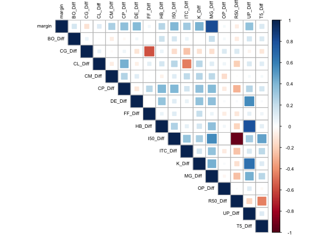

```r
CM1 <-
corrplot(M,
         method = "square",
         type = "upper",
         tl.col= "black",
         tl.cex = 0.6, # Text label color and rotation
         cl.cex = 0.6 # Correlation label color and rotation
         )
```

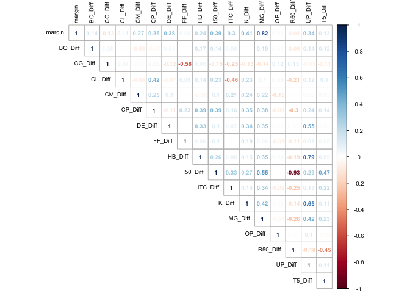

```r
CM2 <-
corrplot(M,
         method = "number",
         type = "upper",
         tl.col="black",
         # tl.srt=45,
         tl.cex = 0.6, # Text label color and rotation
         cl.cex = 0.6, # Correlation label color and rotation
         number.cex = .6
         )
```

In the above Figures, the **top horizontal row of the grid** is of most interest. This row depicts each *statistical-differentials* correlation with the *winning margin*

The immediate stand-out along this row is MG_Diff : **Metres Gained Differential**

What this part of the grid shows is the larger the number of metres gained by the winning team, the greater the winning margin. This is far-and-away the largest correlation of all statistics, which we can characterize as positive & strong **(R = 0.82)**.

Metres Gained has become one of the most fashionable statistics in AFL. An in-depth examination of what it means & does not mean can be read [here](https://www.espn.com.au/afl/story/_/id/27199381/metres-gained-breaking-afl-most-misunderstood-statistic).

It should be acknowledged the gurus at Champion Data have delved into this statistic in much greater depth. My characterization here is simplistic. Much of the nuance which is absent here is covered in this article (for example, delineating *effective* metres gained)

We can look more closely at these relationships via a series of interactive scatterplots:

### Scatterplots

#### winning-Margin x Metres-Gained-Differential

```r
# the greater the MG discrepancy
Matches %>%
  dplyr::select(Home_team, Away_team, WinningTeam, margin, MG_Diff) %>%
  tauchart() %>%
  tau_point("margin", "MG_Diff") %>%
  tau_tooltip()
```

[interactive chart not shown]

Examining the scatterplot of metres gained & winning margin, a few further insights can be gleaned:

- there are very few games where the winning team loses the metres-gained differential **(only 25 out of 207)**
- The highest winning margin for the year for a team conceding the metres-gained statistic was 24 points (Geelong defeating North Melbourne, with a very small -9 metres gained). In other words, if a team does not win the metres gained statistic, they are very unlikely to win by a large margin
- The largest amount of metres gained conceded for a winning team was *-461 metres*, with Fremantle defeating Sydney despite clearly losing the territory battle
- Fremantle were also involved in the only clear outlying game, when they lost to West Coast by 91 points, but conceded only 559 metres (an abnormally small difference when compared to other losses of that margin)

#### Winning-Margin x Disposal-Efficiency-Differential

```r
Matches %>%
  dplyr::select(Home_team, Away_team, WinningTeam, margin, DE_Diff) %>%
  tauchart() %>%
  tau_point("margin", "DE_Diff") %>%
  tau_tooltip()
```

[interactive chart not shown]

One interesting observation between winning margin and disposal efficiency differential is the poorest differential observed for a winning team was -8.7%, recorded by Collingwood in a one point defeat of West-Coast

#### winning-Margin x Number-of-Kicks-Differential

```r
# the greater the MG discrepancy
Matches %>%
  dplyr::select(Home_team, Away_team, WinningTeam, margin, K_Diff) %>%
  tauchart() %>%
  tau_point("margin", "K_Diff") %>%
  tau_tooltip()
```

[interactive chart not shown]

There are four potential outlier matches in this plot, with all involving Richmond. In three of these outliers, Richmond won comfortably, despite recording more than 40 less kicks than there opposition (wins against Sydney, St Kilda & Brisbane).

Inversely, Richmond were defeated by Collingwood in round 2 by 44 points, conceding the equal largest amount of kicks for any game (+107). Other matches with similar kick-differentials resulted in much greater winning margins